# Lab 3B - Regression (Hard)

### 1. Load the Data

1. Import the OS library.

```python
import os
```

2. Set the working directory.

```python
os.chdir("C:\\Workshop\\Data")
```

3. Import the pandas library as "pd".

```python
import pandas as pd
```

4. Read the Rates.csv file into a data frame called *policies*.

```python
policies = pd.read_csv("Rates.csv")
```

### 2. Explore the Data

1. Inspect the policy rates data set using the `head` function.  
*Note: Notice this data set has a numeric Rate variable instead of a categorical Risk variable.*

```python
policies.head()
```

|  | Gender | State | State_Rate | Height | Weight | BMI | Age | Rate |
| --- | --- | --- | --- | --- | --- | --- | --- | --- |
| 0 | Male | MA | 0.100434 | 184 | 67.8 | 20.025992 | 77 | 0.332000 |
| 1 | Male | VA | 0.141723 | 163 | 89.4 | 33.648237 | 82 | 0.869148 |
| 2 | Male | NY | 0.090803 | 170 | 81.2 | 28.096886 | 31 | 0.010000 |
| 3 | Male | TN | 0.119973 | 175 | 99.7 | 32.555102 | 39 | 0.021532 |
| 4 | Male | FL | 0.110345 | 184 | 72.1 | 21.296078 | 68 | 0.149750 |

2. Import the matplotlib pyplot library as "plt".

```python
import matplotlib.pyplot as plt
```

3. Create a scatterplot matrix of the *policies* data set.  
*Note: The semicolon at the end prevents text output from being displayed with the plot.*

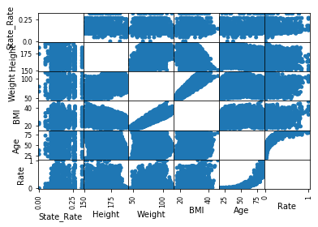

```python
pd.plotting.scatter_matrix(
    frame = policies,
    alpha = 1,
    s = 100,
    diagonal = 'none');
```

4. Create a correlation matrix of the *policies* data set.

```python
correlations = policies.corr()

print(correlations)
```

```
            State_Rate    Height    Weight       BMI       Age      Rate
State_Rate    1.000000 -0.016523  0.009233  0.019241  0.112347  0.226852
Height       -0.016523  1.000000  0.238085 -0.316961 -0.164781 -0.128582
Weight        0.009233  0.238085  1.000000  0.839628  0.011679  0.060939
BMI           0.019241 -0.316961  0.839628  1.000000  0.102317  0.140507
Age           0.112347 -0.164781  0.011679  0.102317  1.000000  0.780079
Rate          0.226852 -0.128582  0.060939  0.140507  0.780079  1.000000
```

5. Import the seaborn library as "sns".

```python
import seaborn as sns
```

6. Create a correlogram using the correlation matrix.

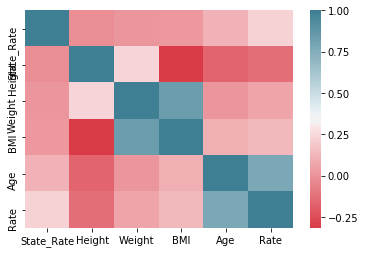

```python
sns.heatmap(
    data = correlations,
    cmap = sns.diverging_palette(
        h_neg = 10,
        h_pos = 220,
        as_cmap=True));
```

7. Question: Which variable is most strongly correlated with Rate?

8. Get the correlation between Age and Rate.

```python
policies.Age \
    .corr(policies.Rate)
```

```
0.7800790487947441
```

9. Create a scatterplot of Rate (on the *y*-axis) vs Age (on the *x*-axis).

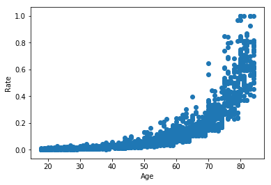

```python
plt.scatter(
    x = policies.Age,
    y = policies.Rate)
plt.xlabel("Age")
plt.ylabel("Rate")
plt.show()
```